# Trait evolution using mvMORPH

Christoph Liedtke

August, 2019

# Intro

Recently, we wanted to test whether a specific trait evolves under different evolutionary models for different subclades of a tree. In our case [genome size in amphibians](https://www.nature.com/articles/s41559-018-0674-4). To fit Brownian motion and Ornstein-Uhlenbeck models, we used Julien Clavel’s mvMORPH R package.

Tree: pruned amphibian tree originally from [Pyron 2014](https://academic.oup.com/sysbio/article/63/5/779/2847944)  
Data: genome sizes (c-values) for amphibian species from [Liedtke et al. 2018](https://www.nature.com/articles/s41559-018-0674-4)

# Loading Data and Libraries

```r
library(mvMORPH)
# install from CRAN or most recent release from github: https://github.com/JClavel/mvMORPH
# make sure dependencies are installed too!
```

```r
### load data:
amphibia_cval<-read.csv("./data/amphibia_cval.csv", row.names = 1, sep=";")

### load tree:
amphibia.tree<-read.tree("./data/amphibia.tre")

### match tree and data order
amphibia_cval<-amphibia_cval[amphibia.tree$tip.label,]
all(rownames(amphibia_cval)==amphibia.tree$tip.label)
```

```
## [1] TRUE
```

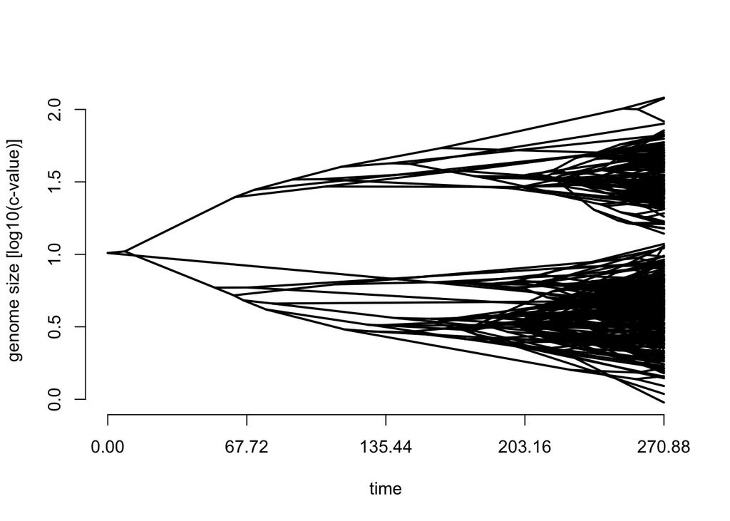

```r
### log transform variable to be normally distributed
amphibia_logC<-log10(amphibia_cval$median_c); names(amphibia_logC)<-rownames(amphibia_cval) # log10 transform data

### plot phenogram to vizualize trait distribution
phenogram(amphibia.tree, amphibia_logC, ftype = "off", ylab="genome size [log10(c-value)]")
```

# Setting up hypotheses

By looking at the phylogenetic distribution of the data, it seemed like salamanders were off doing their own thing with really large genomes (that isolated clade, all with large genomes) we wanted to test whether a single trait model for the whole tree is really best in this case, or whether fitting a multiple optimum/parameters model would be more just. This way we could also test the hypothesis of whether each of the three amphibian orders (Frogs, Salamanders and Caecilians) have evolved under different sets of parameters.

To set up these hypotheses, we created a simmap object using (phytools)[http://blog.phytools.org/], a dependency of mvMORPH, ‘painting’ (i.e. annotating) subclades of the tree that we want to model different processes for.

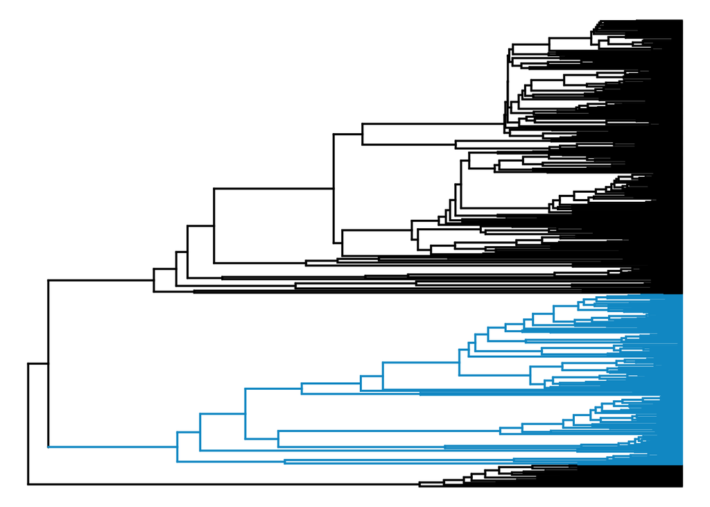

```r
# make a colour scheme to use for vizualizing clades (in this case the three amphibian orders)
cols<-c("black","deepskyblue3","chartreuse3","gold"); names(cols)<-c(1,"caudata","anura","gymno")

# make a simmap object with two 'regimes', comparing salamanders to non-salamanders
two_regimes_tree<-paintSubTree(amphibia.tree,
                               node=getMRCA(amphibia.tree, rownames(amphibia_cval)[amphibia_cval$order=="Urodela"]),
                               state="caudata",
                               stem=T)
plotSimmap(two_regimes_tree,cols,lwd=2,pts=F, ftype="off")
```

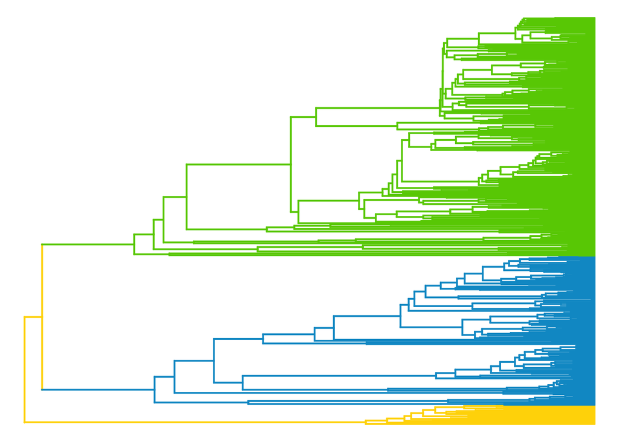

```r
# make a simmap object with three 'regimes' where each of the three amphibian orders is treated separately
three_regimes_tree<-paintSubTree(amphibia.tree,
                                 node=getMRCA(amphibia.tree, rownames(amphibia_cval)[amphibia_cval$order=="Gymnophiona"]),
                                 state="gymno",
                                 stem=T,
                                 anc.state = "gymno")
three_regimes_tree<-paintSubTree(three_regimes_tree,
                                 node=getMRCA(amphibia.tree,rownames(amphibia_cval)[amphibia_cval$order=="Urodela"]),
                                 state="caudata",
                                 stem=T)
three_regimes_tree<-paintSubTree(three_regimes_tree,
                                 node=getMRCA(amphibia.tree,rownames(amphibia_cval)[amphibia_cval$order=="Anura"]),
                                 state="anura",
                                 stem=T)


plotSimmap(three_regimes_tree,cols,lwd=2,pts=F, ftype="off")
```

# Fitting models

With the clades of interest defined, we can now fit BM and OU models. **note: as of late, mvMORPH also allows fitting early burst and shift models too!**

```r
# single optimum/parameter set:
fit_bm1<-mvBM(amphibia.tree, amphibia_logC,model="BM1",echo = F)
```

```
##
##  convergence of the optimizer has not been reached, try simpler model
## a reliable solution has been reached
```

```r
fit_ou1<-mvOU(amphibia.tree, amphibia_logC,model="OU1",echo = F)
```

```
## successful convergence of the optimizer
## a reliable solution has been reached
```

```r
# two optima/parameter sets:
fit_bm2<-mvBM(two_regimes_tree,amphibia_logC,model="BMM", param=list(smean=F),echo = F)
```

```
## successful convergence of the optimizer
## a reliable solution has been reached
```

```r
fit_ou2 <-mvOU(two_regimes_tree,amphibia_logC, model="OUM", param=list(root=F),echo = F)
```

```
## successful convergence of the optimizer
## a reliable solution has been reached
```

```r
# three optima/parameter sets:
fit_bm3<-mvBM(three_regimes_tree,amphibia_logC,model="BMM", param=list(smean=F),echo = T)
```

```
## successful convergence of the optimizer
## a reliable solution has been reached
##
## -- Summary results for multiple rate BMM model --
## LogLikelihood:    288.415
## AIC:      -564.8299
## AICc:     -564.6461
## 6 parameters
##
## Estimated rate matrix
## ______________________
## , , gymno
##
##
##  0.0003795316
##
## , , caudata
##
##
##  0.0002565381
##
## , , anura
##
##
##  0.0005345463
##
##
## Estimated root state
## ______________________
##
## gymno   0.6168402
## caudata 1.6304365
## anura   0.7741864
```

```r
fit_ou3 <-mvOU(three_regimes_tree,amphibia_logC, model="OUM", param=list(root=F),echo = F)
```

```
## successful convergence of the optimizer
## a reliable solution has been reached
```

## Compare model fit

Various things can be done here, for example we can calculate Akaike weights to compare models or we can perform likelihood ratio tests for each type of models (BM or OU)

```r
## compare model fit using Akaike weights:
results<-list(fit_bm1,fit_ou1, fit_bm2, fit_ou2,fit_bm3,fit_ou3)
results<-aicw(results, aicc=TRUE)
results # note, the model names used can be checked in each of the model fit objects.
```

```
## -- Akaike weights --
##               Rank  AIC  diff       wi     AICw
## BMM default 3    1 -567  0.00 1.00e+00 8.03e-01
## BMM default 5    2 -565  2.81 2.46e-01 1.97e-01
## OUM 4            3 -547 20.75 3.13e-05 2.51e-05
## OUM 6            4 -546 21.85 1.80e-05 1.45e-05
## BM1 default 1    5 -530 37.23 0.00e+00 0.00e+00
## OU1 2            6 -528 39.26 0.00e+00 0.00e+00
```

```r
# Test significance with LRT
LRT(fit_bm1, fit_bm2)
```

```
## -- Log-likelihood Ratio Test --
## Model BMM  versus  BM1
## Number of degrees of freedom : 2
## LRT statistic: 41.29293  p-value: 1.079829e-09 ***
## ---
## Signif. codes:  0 '***' 0.001 '**' 0.01 '*' 0.05 '.' 0.1 ' ' 1
```

```r
LRT(fit_bm1, fit_bm3)
```

```
## -- Log-likelihood Ratio Test --
## Model BMM  versus  BM1
## Number of degrees of freedom : 4
## LRT statistic: 42.58177  p-value: 1.263614e-08 ***
## ---
## Signif. codes:  0 '***' 0.001 '**' 0.01 '*' 0.05 '.' 0.1 ' ' 1
```

```r
LRT(fit_bm2,fit_bm3)
```

```
## -- Log-likelihood Ratio Test --
## Model BMM  versus  BMM
## Number of degrees of freedom : 2
## LRT statistic: 1.288839  p-value: 0.5249671
## ---
## Signif. codes:  0 '***' 0.001 '**' 0.01 '*' 0.05 '.' 0.1 ' ' 1
```

```r
LRT(fit_ou1, fit_ou2)
```

```
## -- Log-likelihood Ratio Test --
## Model OUM  symmetric positive  versus  OU1  symmetric positive
## Number of degrees of freedom : 1
## LRT statistic: 20.55006  p-value: 5.809192e-06 ***
## ---
## Signif. codes:  0 '***' 0.001 '**' 0.01 '*' 0.05 '.' 0.1 ' ' 1
```

```r
LRT(fit_ou1, fit_ou3)
```

```
## -- Log-likelihood Ratio Test --
## Model OUM  symmetric positive  versus  OU1  symmetric positive
## Number of degrees of freedom : 2
## LRT statistic: 21.49263  p-value: 2.152453e-05 ***
## ---
## Signif. codes:  0 '***' 0.001 '**' 0.01 '*' 0.05 '.' 0.1 ' ' 1
```

```r
LRT(fit_ou2,fit_ou3)
```

```
## -- Log-likelihood Ratio Test --
## Model OUM  symmetric positive  versus  OUM  symmetric positive
## Number of degrees of freedom : 1
## LRT statistic: 0.9425729  p-value: 0.331617
## ---
## Signif. codes:  0 '***' 0.001 '**' 0.01 '*' 0.05 '.' 0.1 ' ' 1
```

The AIC comparison suggests that the best model was a Brownian motion model with multiple sets of parameters, one for salamanders and one for everything else (‘BMM default 3 model’ in the Akeike weights table), but the likelihood ratio test was less clear about this, suggesting that that the 2 and 3 parameter sets performed equally well (or at least not significantly better or worse).

# Ancestral state reconstruction

Seeing as the 2 and 3 parameter sets performed best, we are going to reconstruct ancestral states with these. Although BM outperformed OU, just as an example, I will reconstruct ancestral states with both.

```r
# BM (2 parameter model)
bm2.asr.fit<-mvBM(two_regimes_tree,amphibia_logC,model="BMM", param=list(smean=F))
```

```
## successful convergence of the optimizer
## a reliable solution has been reached
##
## -- Summary results for multiple rate BMM model --
## LogLikelihood:    287.7705
## AIC:      -567.5411
## AICc:     -567.4539
## 4 parameters
##
## Estimated rate matrix
## ______________________
## , , 1
##
##
##  0.0005240248
##
## , , caudata
##
##
##  0.0002566532
##
##
## Estimated root state
## ______________________
##
## 1       0.6642491
## caudata 1.6354438
```

```r
bm2.asr.estim<-estim(two_regimes_tree, amphibia_logC, bm2.asr.fit, asr=TRUE)

# BM (3 parameter model)
bm3.asr.fit<-mvBM(three_regimes_tree,amphibia_logC,model="BMM", param=list(smean=F))
```

```
## successful convergence of the optimizer
## a reliable solution has been reached
##
## -- Summary results for multiple rate BMM model --
## LogLikelihood:    288.415
## AIC:      -564.8299
## AICc:     -564.6461
## 6 parameters
##
## Estimated rate matrix
## ______________________
## , , gymno
##
##
##  0.0003795316
##
## , , caudata
##
##
##  0.0002565381
##
## , , anura
##
##
##  0.0005345463
##
##
## Estimated root state
## ______________________
##
## gymno   0.6168402
## caudata 1.6304365
## anura   0.7741864
```

```r
bm3.asr.estim<-estim(three_regimes_tree, amphibia_logC, bm3.asr.fit, asr=TRUE)


# OU (2 parameter model)
ou2.asr.fit<-mvOU(two_regimes_tree,amphibia_logC,model="OUM", param=list(root=F))
```

```
## successful convergence of the optimizer
## a reliable solution has been reached
##
## -- Summary results --
## LogLikelihood:    277.3975
## AIC:      -546.795
## AICc:     -546.7078
## 4 parameters
##
## Estimated theta values
## ______________________
##
## 1       0.6399487
## caudata 2.2490503
##
## ML alpha values
## ______________________
##
##  0.003615548
##
## ML sigma values
## ______________________
##
##  0.000500618
```

```r
ou2.asr.estim<-estim(two_regimes_tree, amphibia_logC, ou2.asr.fit, asr=TRUE)

# OU (3 parameter model)
ou3.asr.fit<-mvOU(three_regimes_tree,amphibia_logC,model="OUM", param=list(root=F))
```

```
## successful convergence of the optimizer
## a reliable solution has been reached
##
## -- Summary results --
## LogLikelihood:    277.8688
## AIC:      -545.7375
## AICc:     -545.6065
## 5 parameters
##
## Estimated theta values
## ______________________
##
## gymno   0.7781379
## caudata 2.0813825
## anura   0.4916251
##
## ML alpha values
## ______________________
##
##  0.003975036
##
## ML sigma values
## ______________________
##
##  0.0005099655
```

```r
ou3.asr.estim<-estim(three_regimes_tree, amphibia_logC, ou3.asr.fit, asr=TRUE)
```

We can now visualize these reconstructions using phenograms for example:

```r
## BM
#2 means
bm2.asr.states<-10^c(amphibia_logC,bm2.asr.estim$estimates) # The key here is to paste the tip states together with the node states estimated by mvMORPH as one vector. Here I am converting log10() traits back to real space so that I can plot a y axis on a log scale. this is not necesary, but I think it is more easily interpreted this way.
names(bm2.asr.states)[names(bm2.asr.states)==""]<-which(names(bm2.asr.states)=="") # some nodes don't have node numbers, which confuses phenogram() so this is just to make sure they are all numbered nicely

par(mfrow=c(2,2))
par(mar=c(4,4,1,1))
phenogram(tree=two_regimes_tree,x=bm2.asr.states, ftype="off", ylim=c(1,120), log="y", colors=cols)
```

[output not shown]

[output cut: 101 more lines]

[output not shown]

```r
#3 means
bm3.asr.states<-10^c(amphibia_logC,bm3.asr.estim$estimates)
names(bm3.asr.states)[names(bm3.asr.states)==""]<-which(names(bm3.asr.states)=="")

par(mar=c(4,4,1,1))
phenogram(tree=three_regimes_tree,x=bm3.asr.states, ftype="off", ylim=c(1,120), log="y", colors=cols)
```

[output not shown]

[output cut: 101 more lines]

[output not shown]

```r
## OU
#2 optima
ou2.asr.states<-10^c(amphibia_logC,ou2.asr.estim$estimates)
names(ou2.asr.states)[names(ou2.asr.states)==""]<-which(names(ou2.asr.states)=="")

par(mar=c(4,4,1,1))
phenogram(tree=two_regimes_tree,x=ou2.asr.states, fsize=0.0001, spread.labels=F, ylim=c(1,120), log="y", colors=cols, ftype="reg")
```

[output not shown]

[output cut: 101 more lines]

[output not shown]

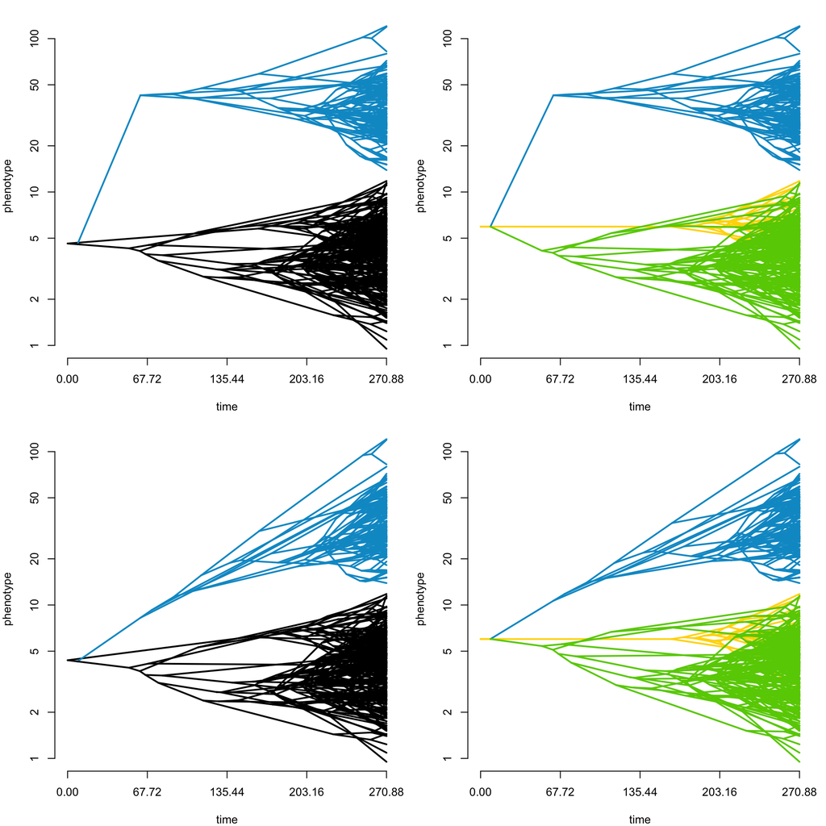

[output not shown]

[output cut: 101 more lines]

[output not shown]

```r
#3 optima
ou3.asr.states<-10^c(amphibia_logC,ou3.asr.estim$estimates)
names(ou3.asr.states)[names(ou3.asr.states)==""]<-which(names(ou3.asr.states)=="")

par(mar=c(4,4,1,1))
phenogram(tree=three_regimes_tree,x=ou3.asr.states, fsize=0.0001, spread.labels=F, ylim=c(1,120), log="y", colors=cols, ftype="reg")
```

# Simulating traits

Now that we have established the best model(s), we might also want to see whether any species or clades in particular may be outliers, i.e. showing trait histories diverging from the expected. To do this, we can simulate trait histories under the given models to get a distribution of trait values per species.

```r
# Simulate
simul_bm2<-mvSIM(two_regimes_tree,nsim=10000, model="BMM",param=fit_bm2)

# Find species that fall outside 90% confidence intervals
simul_bm2.ci<-t(apply(FUN=quantile, c(0.05, 0.95), MARGIN = 1, X = simul_bm2))
simul_bm2.outliers<-which(simul_bm2.ci[,1] > amphibia_logC | simul_bm2.ci[,2] < amphibia_logC)
simul_bm2.outliers
```

```
##              Necturus_lewisi           Necturus_punctatus
##                           93                           94
##         Desmognathus_wrighti Desmognathus_quadramaculatus
##                          108                          109
##     Desmognathus_ochrophaeus          Desmognathus_fuscus
##                          111                          113
##    Petropedetes_cameronensis        Platyplectrum_ornatum
##                          265                          337
```

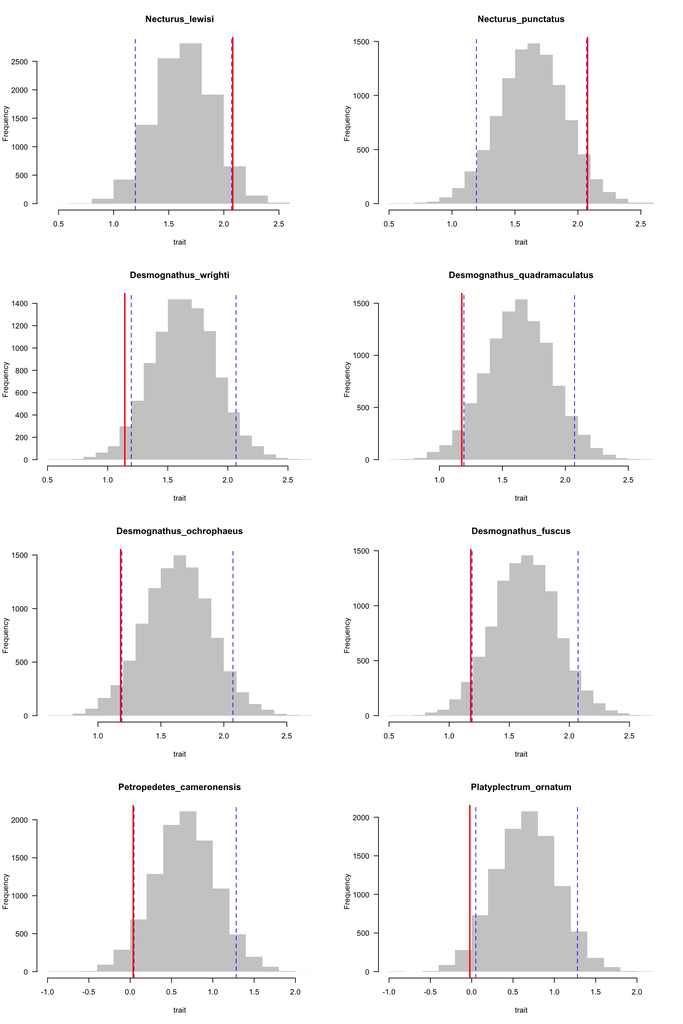

```r
# plot expected distributions and true trait values
par(mfrow=c(4,2))
for(i in 1:length(simul_bm2.outliers)){
  hist(simul_bm2[names(simul_bm2.outliers)[i],], main=names(simul_bm2.outliers)[i], cex=0.5, xlab="trait",las=1, border=NA, col="grey80")
  abline(v=quantile(simul_bm2[names(simul_bm2.outliers)[i],], c(0.05, 0.95)), col="blue", lwd=1, lty=2) # quantile bands
  abline(v=amphibia_logC[names(simul_bm2.outliers)[i]], col="red", lwd=2) # true value
}
```

## Simulating ancestral states

I couldn’t find a way to get ancestral states for trait simulations (maybe there is a good reason for this), and so my work around has been to just perform ancestral state reconstructions on the simulated states. This seems somewhat circular to me, and so I want to put a big *disclaimer* here that maybe this isn’t the best way to go about doing things.

```r
node.sim<-list()
## NOTE: here i am just using the first 100 simulations, but ideally you would run the loop for 1:ncol(simul_bm2)
for(i in 1:100){
  node.sim[[i]]<-estim(two_regimes_tree, simul_bm2[,i], bm2.asr.fit, asr=TRUE)$estimates[,1]
}
node.sim<-as.data.frame(t(do.call(rbind, node.sim)))

# Now you have a table of node states for each simulated trait set (simulations as columns)
# the root note will inevitably be the same for all simulations as this is the nature of a BM model:
node.sim[1,]
```

```
##            V1        V2        V3        V4        V5        V6        V7
## 465 0.6642491 0.6642491 0.6642491 0.6642491 0.6642491 0.6642491 0.6642491
##            V8        V9       V10       V11       V12       V13       V14
## 465 0.6642491 0.6642491 0.6642491 0.6642491 0.6642491 0.6642491 0.6642491
##           V15       V16       V17       V18       V19       V20       V21
## 465 0.6642491 0.6642491 0.6642491 0.6642491 0.6642491 0.6642491 0.6642491
##           V22       V23       V24       V25       V26       V27       V28
## 465 0.6642491 0.6642491 0.6642491 0.6642491 0.6642491 0.6642491 0.6642491
##           V29       V30       V31       V32       V33       V34       V35
## 465 0.6642491 0.6642491 0.6642491 0.6642491 0.6642491 0.6642491 0.6642491
##           V36       V37       V38       V39       V40       V41       V42
## 465 0.6642491 0.6642491 0.6642491 0.6642491 0.6642491 0.6642491 0.6642491
##           V43       V44       V45       V46       V47       V48       V49
## 465 0.6642491 0.6642491 0.6642491 0.6642491 0.6642491 0.6642491 0.6642491
##           V50       V51       V52       V53       V54       V55       V56
## 465 0.6642491 0.6642491 0.6642491 0.6642491 0.6642491 0.6642491 0.6642491
##           V57       V58       V59       V60       V61       V62       V63
## 465 0.6642491 0.6642491 0.6642491 0.6642491 0.6642491 0.6642491 0.6642491
##           V64       V65       V66       V67       V68       V69       V70
## 465 0.6642491 0.6642491 0.6642491 0.6642491 0.6642491 0.6642491 0.6642491
##           V71       V72       V73       V74       V75       V76       V77
## 465 0.6642491 0.6642491 0.6642491 0.6642491 0.6642491 0.6642491 0.6642491
##           V78       V79       V80       V81       V82       V83       V84
## 465 0.6642491 0.6642491 0.6642491 0.6642491 0.6642491 0.6642491 0.6642491
##           V85       V86       V87       V88       V89       V90       V91
## 465 0.6642491 0.6642491 0.6642491 0.6642491 0.6642491 0.6642491 0.6642491
##           V92       V93       V94       V95       V96       V97       V98
## 465 0.6642491 0.6642491 0.6642491 0.6642491 0.6642491 0.6642491 0.6642491
##           V99      V100
## 465 0.6642491 0.6642491
```

We could now look at the individual distributions per node if we are interested in a particular one, for example what would be the distribution of traits for the most recent common ancestor of salamanders:

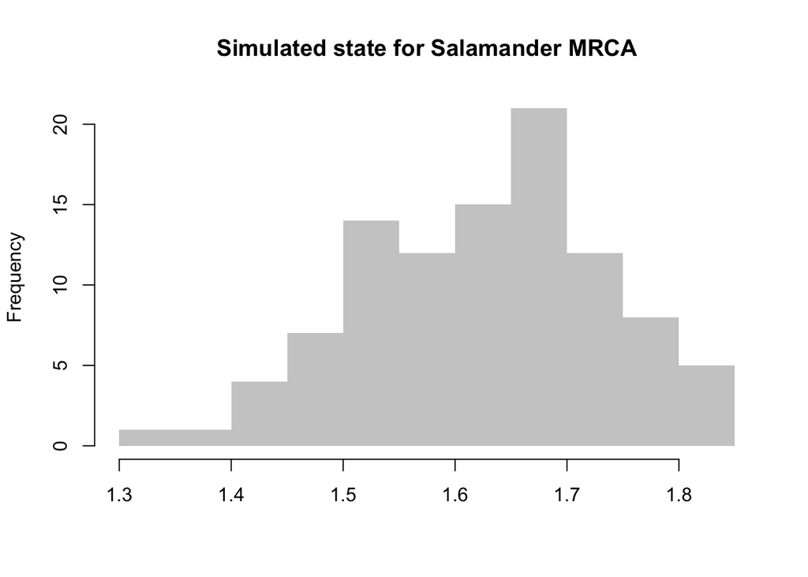

```r
hist(as.numeric(node.sim["488",]), main="Simulated state for Salamander MRCA", xlab=NA, col="grey80", border=NA)
```

Using the `ggtree` package, we could also plot these histograms directly on the nodes of the tree. To do this, I borrowed a bit of code from [here](http://www.randigriffin.com/2017/05/11/primate-phylogeny-ggtree.html).

```r
library(ggtree)
```

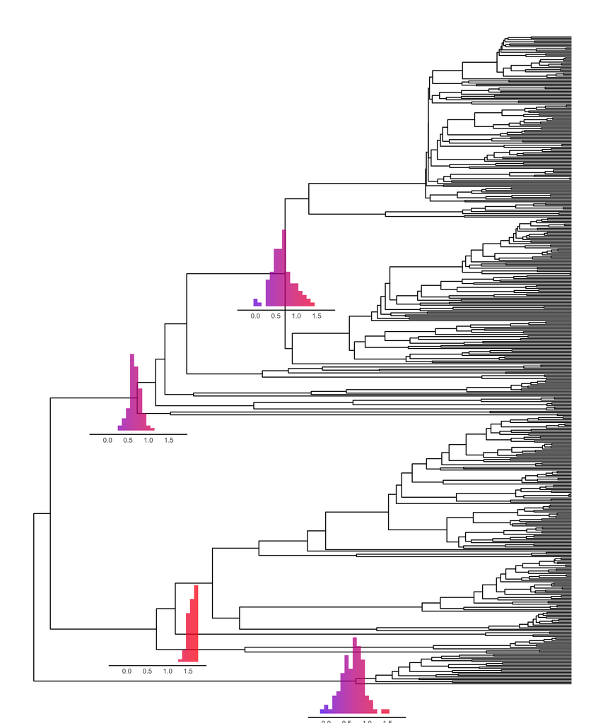

```r
library(ggplot2)

# make ggtee object
gtree<-ggtree(amphibia.tree)

# define vector with node numbers as character strings for which we want to plot the histograms
nodes <- c("466","488","657","694")

# make the node annotation object
pd <- as.data.frame(node.sim[nodes,])
pdplots <- apply(pd, 1, function(y) {
  ggplot(data.frame(y=y), aes(y, fill=..x..)) +
    geom_histogram(binwidth = 0.1, alpha=0.75) +
    xlim(range(unlist(pd))) +
    scale_fill_gradient(low = "blue", high = "red") +
    theme_inset() +
    theme(axis.line.x = element_line(color="black", size = 0.5),
          axis.text.x = element_text(size=8))
})

# plot tree and nodes
inset(gtree, pdplots, width=0.5, height=0.25, vjust=-1)
```